# Homework 3 SDS315

Jade Lightfoot (jsl3652)

Github Repo link: https://github.com/JadeLightfoot/Homework-4-SDS315

# **Problem 1: Gas Station**

### **Theory A**

**Claim**: This theory states, “Gas stations charge more if they lack direct competition in sight”.

**Evidence**: The box plots below display the relationship of if a gas station has a competitor or not, and its price.

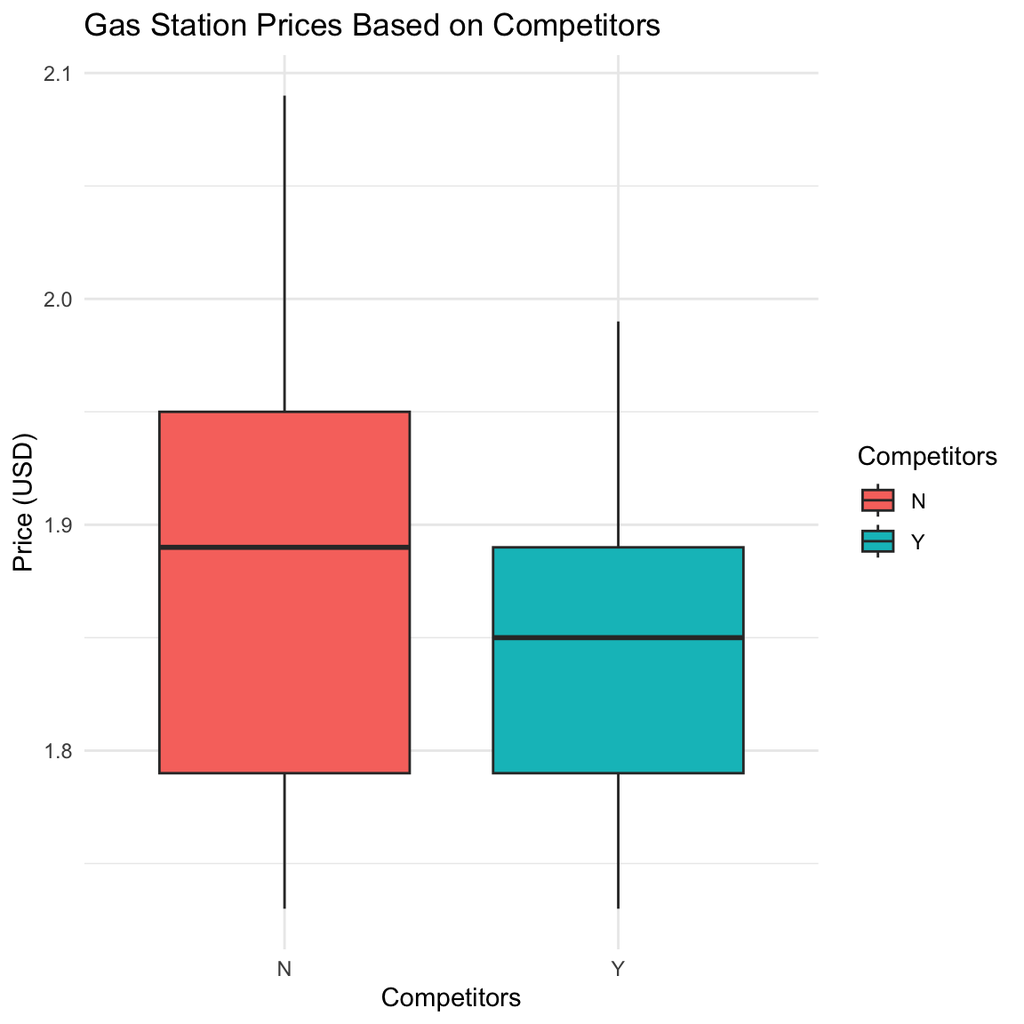

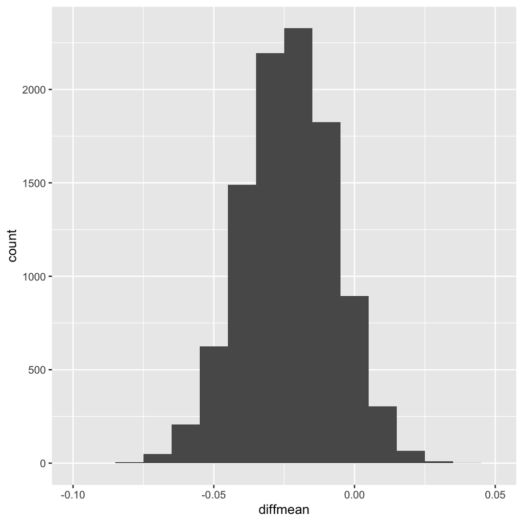

| name | lower | upper | level | method | estimate |
| --- | --- | --- | --- | --- | --- |
| diffmean | -0.0553414 | 0.0083284 | 0.95 | percentile | -0.0234824 |

### **Theory B**

**Claim**: This theory states, “The richer the area, the higher the gas prices.”

**Evidence**:

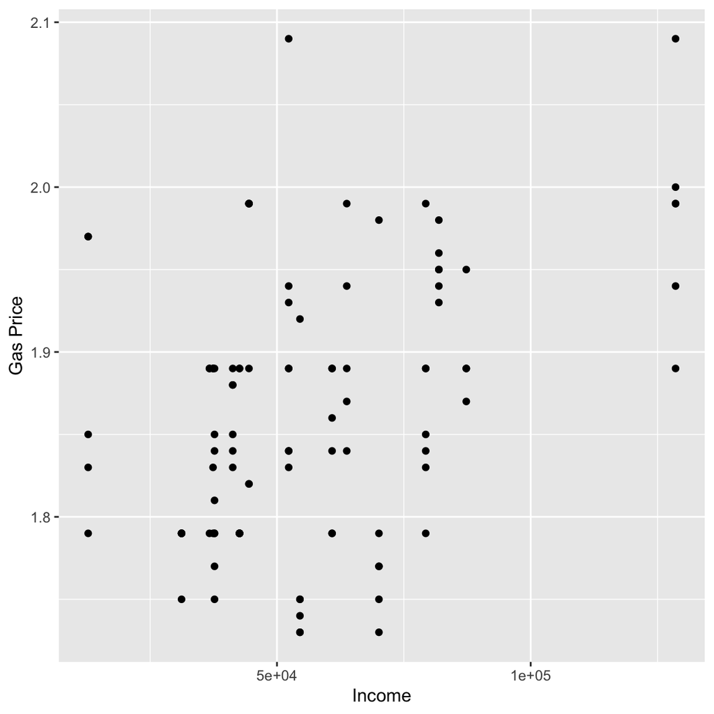

| name | lower | upper | level | method | estimate |
| --- | --- | --- | --- | --- | --- |
| Intercept | 1.7593181 | 1.8299684 | 0.95 | percentile | 1.7934425 |
| Income | 0.0000007 | 0.0000018 | 0.95 | percentile | 0.0000012 |
| sigma | 0.0638486 | 0.0850586 | 0.95 | percentile | 0.0752228 |
| r.squared | 0.0381966 | 0.3246478 | 0.95 | percentile | 0.1569385 |
| F | 3.9316388 | 47.5901877 | 0.95 | percentile | 18.4291561 |

### **Theory C**

**Claim**: This theory states, “Gas stations at stoplights charge more.”

**Evidence**:

| Stoplight | Mean_Price | Median_Price | Proportion |
| --- | --- | --- | --- |
| N | 1.866316 | 1.84 | 0.3762376 |
| Y | 1.863016 | 1.87 | 0.6237624 |

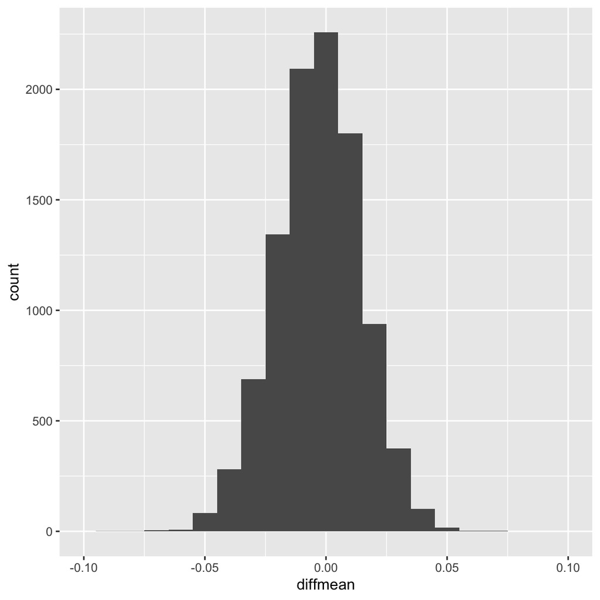

| name | lower | upper | level | method | estimate |
| --- | --- | --- | --- | --- | --- |
| diffmean | -0.0382771 | 0.0304798 | 0.95 | percentile | -0.0032999 |

This table shows the proportion of gas stations that are near a stoplight (Y) and not near a stoplight (N). It also displays the mean and median of the gas prices based on if the gas station was near a stoplight or not. Based on the table the mean and median prices are similarly close to one another for the gas stations, but when looking at the proportion there is more gas stations located near a stoplight. When calculating the difference of means between gas stations near and not near a stoplight the difference was .003. This difference does not necessarily hold any significance due to its closeness to zero. Meaning that the claim “Gas stations at stoplights charge more.” can not be heavily supported. Based on the evidence above the difference of means estimate is -.003 and the difference between gas station prices near a stoplight is somewhere between -0.038 and 0.030, with 95% confidence.

**Conclusion**: To conclude, based on the evidence for the claim that “Gas stations at stoplights charge more.”, one can conclude that the evidence does not support the claim.

### **Theory D**

**Claim**: This theory states that, “Gas Stations with direct highway access charge more.”

**Evidence**:

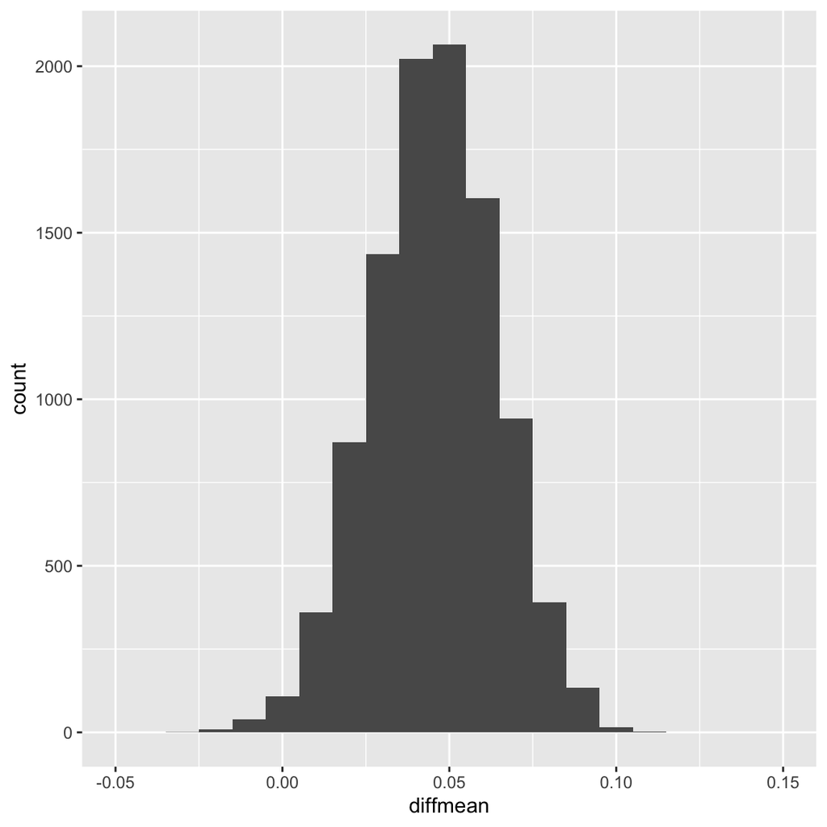

| name | lower | upper | level | method | estimate |
| --- | --- | --- | --- | --- | --- |
| diffmean | 0.0088702 | 0.0807836 | 0.95 | percentile | 0.0456962 |

**Conclusion**: Based on the evidence the claim that “Gas Stations with direct highway access charge more.” is supported through the confidence interval and estimated mean.

### **Theory E**

**Claim**: This theory states, “Shell charges more than all other non-Shell brands.”

**Evidence**:

| name | lower | upper | level | method | estimate |
| --- | --- | --- | --- | --- | --- |
| prop_TRUE | 0.1980198 | 0.3762376 | 0.95 | percentile | 0.2871287 |

**Conclusion**: Based on the evidence the claim that “Shell charges more than all other non-Shell brands.”it is not supported by the evidence.

# **Problem 2: Mercedes S-Class**

### **Part A**

| name | lower | upper | level | method | estimate |
| --- | --- | --- | --- | --- | --- |
| diffmean | -1060.43 | 9767.08 | 0.95 | percentile | 4268.371 |

### **Part B**

| name | lower | upper | level | method | estimate |
| --- | --- | --- | --- | --- | --- |
| prop_TRUE | 0.4164071 | 0.4527518 | 0.95 | percentile | 0.4323295 |

The proportion for a 95% confidence interval of all 2014 S-Class 550s that were painted black is somewhere between 0.42 and 0.45.

# **Problem 3: NBC Network Shows**

### **Part A**

**Question:** The question I am trying to answer is, if there is evidence that one show consistently produces a higher mean for Question 1- Happy response among its viewers.

**Approach:** To answer this question I used the confint function and performed a 95 % confidence interval to find evidence for viewer response regarding the shows “Living with Ed” and “My name is Earl”.

**Results:**

| name | lower | upper | level | method | estimate |
| --- | --- | --- | --- | --- | --- |
| diffmean | -0.3951221 | 0.1050476 | 0.95 | percentile | -0.1490515 |

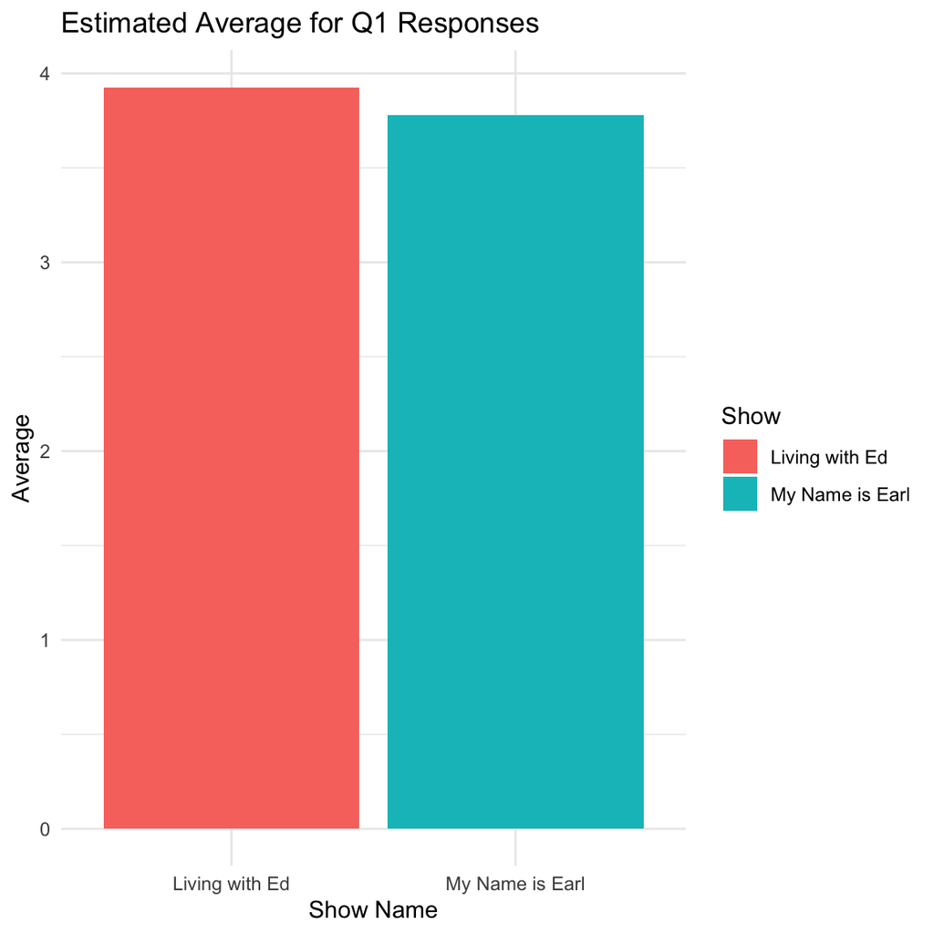

In order to answer the question I made a table displaying the confidence interval data for difference of means and also made a bar graph to display the averages for both shows.

**Conclusion** To conclude there is no significant evidence to show that one show consistently produces a higher mean. The estimated means are very close and when running a 95% confidence interval somewhere between -0.40 and .11. Because of the interval and the true mean lying somewhere in between the two numbers further investigation between the two shows would have to be conducted.

### **Part B**

**Question:** The question that needs to be answered is which reality/ contest show (“The Biggest Loser” and “The Apprentice: Los Angeles”) made people feel more annoyed, and is there evidence that show one show consistently producing a higher mean in the Q1_Annoyed response among viewers.

**Approach:** For this question i will use the function confint to for find the confidence interval as well as bootstrap a sample. I will construct this by filtering a data set that only contains “The Biggest Loser” and “The Apprentice: Los Angeles”.

**Results:**

| name | lower | upper | level | method | estimate |
| --- | --- | --- | --- | --- | --- |
| diffmean | -0.5186703 | -0.0217746 | 0.95 | percentile | -0.270997 |

These results provide a table that shows a 95% confidence interval for the difference in means for the shows “The Biggest Loser” and “The Apprentice: Los Angeles” after running a bootstrap.

**Conclusion** To conclude because the 95% confidence interval is between -0.52 and -0.02 there is statistical significance because the value of zero is not between these two numbers. Meaning that one show consistently produces more annoyance than the other. To answer the question of which show , “The Apprentice: Los Angeles” had the higher mean for the show being considered annoying. Therefore, this show may not be a hit with viewers.

### **Part C**

**Question:** The question is what proportion of American TV watchers would we expect to give a response 4 or greater to the “Q2_Confusing” question for the show “Dancing With the Stars”.

**Approach:** For this question I will use confint to find the confidence interval of proportions and by constructing a confidence interval by bootstrapping the DWTS (Dancing With The Stars) filtered data it should help answer the question.

# **Problem 4: EBay**

**Question:** The question that needs to be answered is, “…assess the evidence for whether the revenue ratio is the same in the treatment and control groups, or whether instead the data favors the idea that paid search advertising on Google creates extra revenue for EBay”.

**Approach:** In order to answer this question the statistical approach used was constructing a confidence interval, by bootstrapping.